# ape and phangorn

Klaus Schliep

University of Massachusetts Boston

klaus.schliep@gmail.com

6/14/2019

#### Abstract

A short introduction to ape and phangorn

# 1 Getting started

## 1.1 Installation

If haven’t done it you can install ape and phangorn from [CRAN](https://cran.r-project.org/)

```r
install.packages("ape", "phangorn")
```

To test bleeding edge features or help with the development you may want install the development version of *ape* or *phangorn*

Emmanuel provides an ape development to download [here](http://ape-package.ird.fr/ape_installation.html).

You can install the development version for phangorn from github:

```r
# install.packages("remotes")
remotes::install_github("KlausVigo/phangorn")
```

To compile these packages you may need to install on windows [Rtools](https://cran.r-project.org/bin/windows/Rtools/) and on mac [XCode](https://developer.apple.com/xcode/) and [GFortran](https://gcc.gnu.org/wiki/GFortranBinaries). Linux should work out of the box.

To install the development version of phangorn you may need to install the Biostrings and seqLogo package from bioconductor first:

```
if (!requireNamespace("BiocManager", quietly = TRUE))
    install.packages("BiocManager")
BiocManager::install(c("Biostrings", "seqLogo"))
```

## 1.2 Getting help

So many functions … how to find/remember them?

- write scripts (and maintain them!)
- `help.start()`
- ?… (or `help("...")`)
- `apropos("...")`
- use TAB-completion (or a “cool” editor)

You can run the code examples in a help file with `example(plot.phylo)`.

Operators are also functions:

```r
get("+")
```

```
## function (e1, e2)  .Primitive("+")
```

```r
'+'(1, 2)
```

```
## [1] 3
```

Many packages provide vignettes with some small workflows.

```r
# what vignettes are in package phangorn
vignette(package="phangorn")
# open one:
vignette("IntertwiningTreesAndNetworks")
```

Apart from Google you can ask questions and search for answers on r-sig-phylo, [biostars](https://www.biostars.org/) or [stackoverflow](https://stackoverflow.com/), but respect the community and do not cross-post.

## 1.3 The class “phylo” and “multiPhylo”

```r
library(ape)
library(phangorn)
library(magrittr)
```

The class *phylo* represents phylogenetic trees is defined in *ape* and used in many other packages.

To import a tree phylogenetic tree

- `read.tree`: Newick files
- `read.nexus`: Nexus files (tree block only)
- `read.evonet`: Extended Newick format

and to export trees we can use

- `write.tree`: Newick files
- `write.nexus`: Nexus files (tree block only)
- `write.evonet`: Extended Newick format

If there is only one tree in the file we read in the object returned is of class `phylo`, otherwise the object is of class `multiPhylo`. `multiPhylo` is a mainly a list of trees of class `phylo`.

Let’s start with reading in a small tree

```r
tree <- read.tree(text= "((a:1,b:1):1,c:2);")
tree
```

```
##
## Phylogenetic tree with 3 tips and 2 internal nodes.
##
## Tip labels:
## [1] "a" "b" "c"
##
## Rooted; includes branch lengths.
```

and have a look at the internal structure

```r
str(tree)
```

```
## List of 4
##  $ edge       : int [1:4, 1:2] 4 5 5 4 5 1 2 3
##  $ edge.length: num [1:4] 1 1 1 2
##  $ Nnode      : int 2
##  $ tip.label  : chr [1:3] "a" "b" "c"
##  - attr(*, "class")= chr "phylo"
##  - attr(*, "order")= chr "cladewise"
```

```r
tree$edge
```

```
##      [,1] [,2]
## [1,]    4    5
## [2,]    5    1
## [3,]    5    2
## [4,]    4    3
```

It makes a bit more sense when we plot the tree

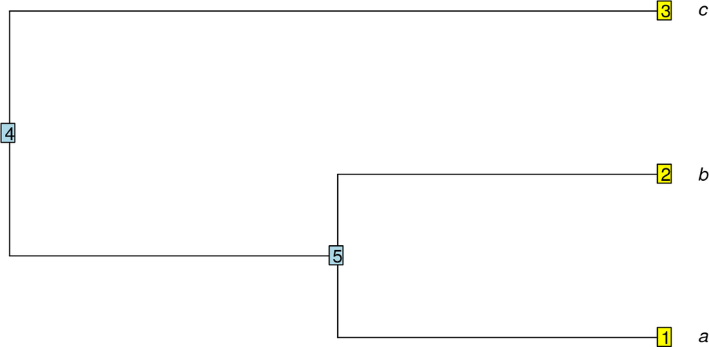

```r
plot(tree, label.offset=.1)
nodelabels()
tiplabels()
```

Here we used already the generic function `plot.phylo` to plot the tree. `plot.phylo` has a lot of parameters to adopt the plot to your needs.

Run

```
example(plot.phylo)
```

and

```
example(phydataplot)
```

to get a glimpse of the graphical capabilities. If you prefer a basic GUI interface try [shinyTreeViewer](http://klash.shinyapps.io/shinyTreeViewer/).

Over the time a huge set of generic functions have been developed. Some of the functions I frequently use are:

```
root(phy, outgroup, ...)
midpoint(x)
drop.tip(phy, tip, ...)
keep.tip(phy, tip, ...)
extract.clade(phy, node, ...)
bind.tree(x, y, ...)
ladderize(phy)
unroot(phy)
multi2di(phy, random = TRUE)
di2multi(phy, tol = 1e-8)
rotate(phy, node)
rotateConstr(phy, X)
reorder(phy)
```

You can list all the function with

```
methods(class="phylo")
methods(class="multiPhylo")
```

Now lets do a bit more interesting example. First we download some MCMC tree sample from Dan folder.

```r
trees_1 <- read.nexus("../7 - Dan Warren - MCMC convergence diagnostics using RWTY/fungus trees/fungus1.t")
trees_1
```

```
## 2001 phylogenetic trees
```

```r
class(trees_1)
```

```
## [1] "multiPhylo"
```

If this should not work my favorite function in an interactive session is `file.choose()`. In this case try `trees_1 <- read.nexus(file.choose())` and navigate to the file.

`multiPhylo` objects can be in two forms: compressed or not. A compressed tree list cannot have duplicated tip labels. Do you need more details: `?.compressTipLabel`, `?multiphylo`.

The functions `di2multi`, `multi2di`, `Ntip`, `Nnode`, `Nedge`, `reorder`, `is.ultrametric`, `root`, `unroot`, `is.rooted`, and `is.binary` are generic and work on objects of class `phylo` and `multiPhylo`.

We can use on objects of class `multiPhylo` the classical operators on lists, `[`, `[[`, `$` (in both ways: extraction or assignment). As `trees_1` is an MCMC sample we may discard the burn-in

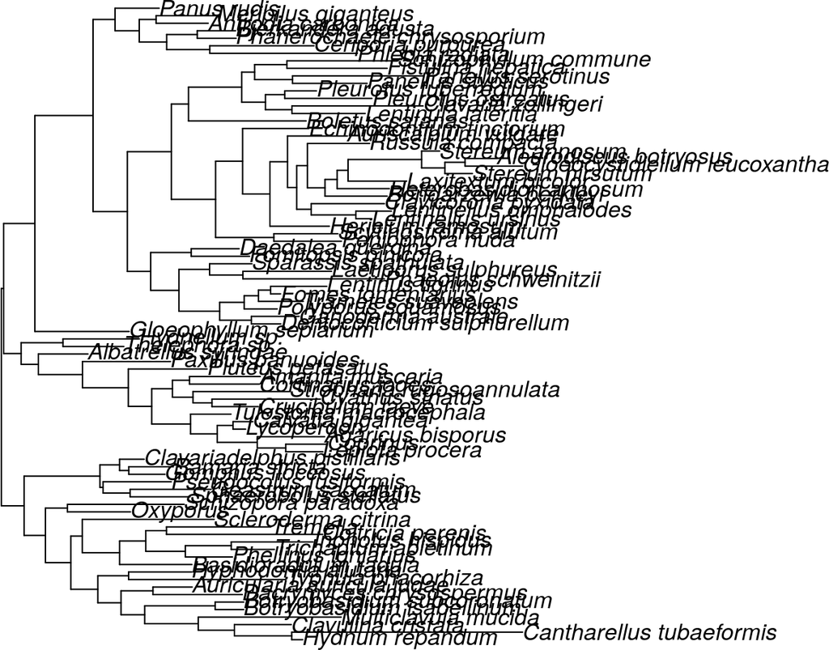

```r
trees_1 <- trees_1[-c(1:1001)]
par(mar = c(0,0,0,0))
midpoint(trees_1[[1]]) %>% plot()
```

Not bad for the start, but the labels are too long.

*ape* has implemented several functions dedicated to string manipulation

```
abbreviateGenus(x, genus = TRUE, species = FALSE, sep = NULL)
stripLabel(x, species = FALSE, subsp = TRUE, sep = NULL)
label2table(x, sep = NULL, as.is = FALSE)
makeLabel(x, len = 99, space = "_", make.unique = TRUE,
          illegal = "():;,[]", quote = FALSE, ...)
updateLabel(x, old, new, exact = TRUE, ...)
mixedFontLabel(..., sep = " ", italic = NULL, bold = NULL, parenthesis = NULL,
               always.upright = c("sp.", "spp.", "ssp."))
```

Let’s use `abbreviateGenus` on the `trees_1`. As we have an compressed version we need to do this only once.

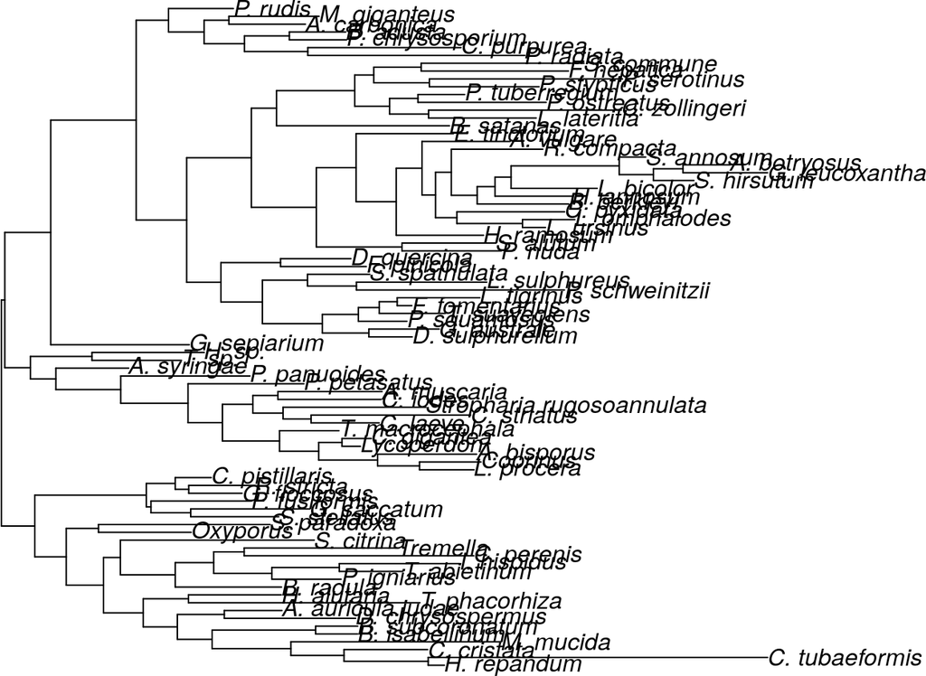

```r
attr(trees_1, "TipLabel") <- abbreviateGenus(attr(trees_1, "TipLabel"))
par(mar = c(0,0,0,0))
midpoint(trees_1[[1]]) %>% plot()
```

Next we want to explore these trees a bit more. Let’s start with different types of consensus trees on our MCMC sample.

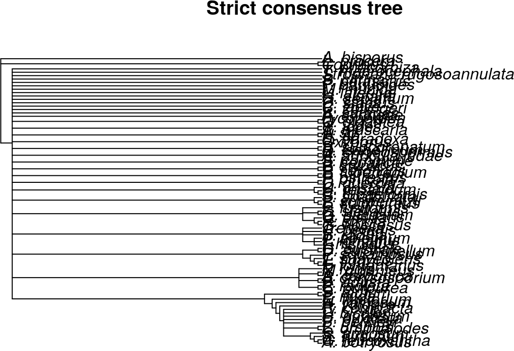

```r
strict_consensus <- consensus(trees_1)
majority_consensus <- consensus(trees_1, p=.5)
all_compat <- allCompat(trees_1)
max_clade_cred <- maxCladeCred(trees_1)
plot(strict_consensus, main="Strict consensus tree")
```

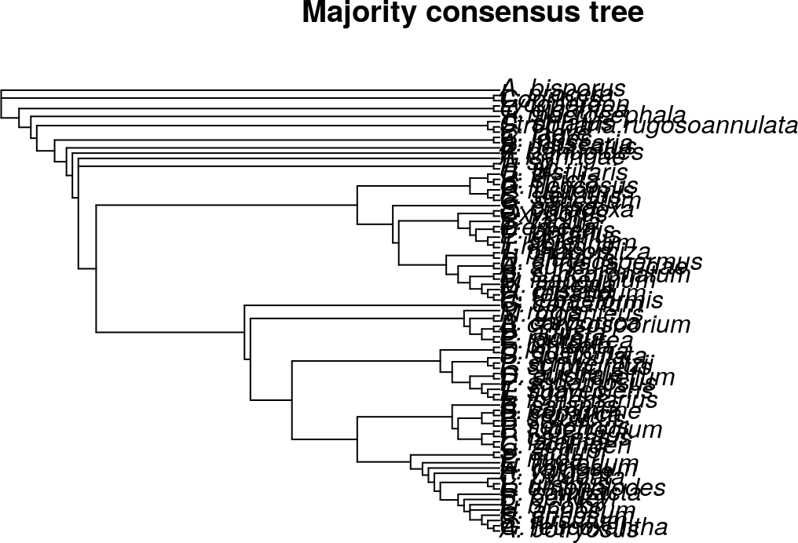

```r
plot(majority_consensus, main="Majority consensus tree")
```

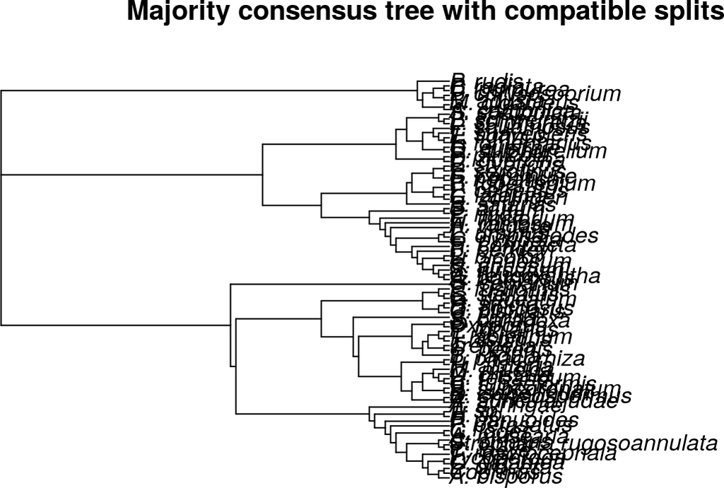

```r
plot(all_compat, main="Majority consensus tree with compatible splits")
```

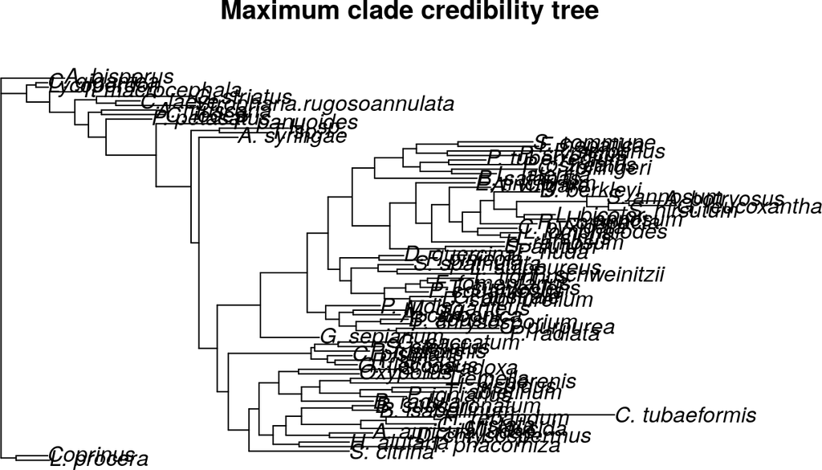

```r
plot(max_clade_cred, main="Maximum clade credibility tree")
```

If you want to know more: `?consensus`, `?maxCladeCred`.

# 2 Phylogenetic networks

A generalization of a consensus tree is the consensusNet Holland et al. (2004).

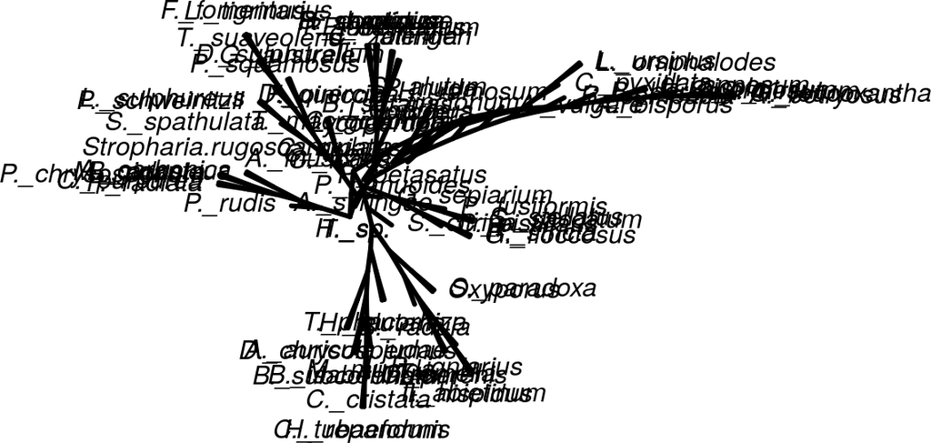

```r
cnet <- consensusNet(trees_1, p=.25)
plot(cnet, "equal")
```

A pretty cool feature is the possibility to plot networks in 3D. You need to have the rgl package installed to use this feature, which can be sometimes tricky to install.

```
plot(cnet, "3D")
```

## 2.1 Coloring edges

Coloring edges in trees and especially networks can be tricky. The next example from Schliep et al. (2017) shows how to do this.

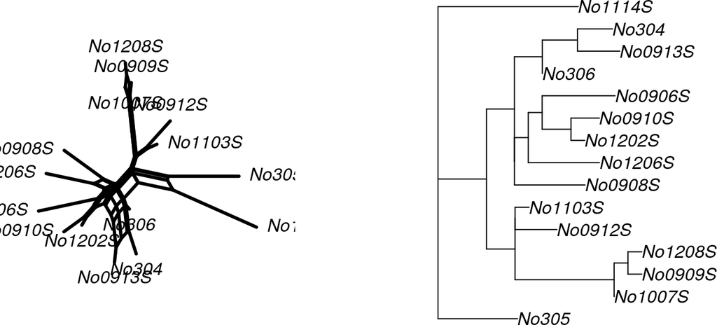

```r
# we create a path to the files we want to load
fdir <- system.file("extdata/trees", package = "phangorn")
## NeigbourNet Nexus file generated by SplitsTree (from previous analysis)
Nnet <- read.nexus.networx(file.path(fdir,"woodmouse.nxs"))
## RAxML best-known tree with bipartition support (from previous analysis)
raxml.tree <- read.tree(file.path(fdir,"RAxML_bipartitions.woodmouse"))

par(mfrow=c(1,2))
# NeighbourNet
plot(Nnet,"equal")
#plot the tree
plot(raxml.tree)
```

We want to identify edges in a neighbour-net (NN) network that correspond to branches / edges in a tree (a maximum likelihood tree, in this case).

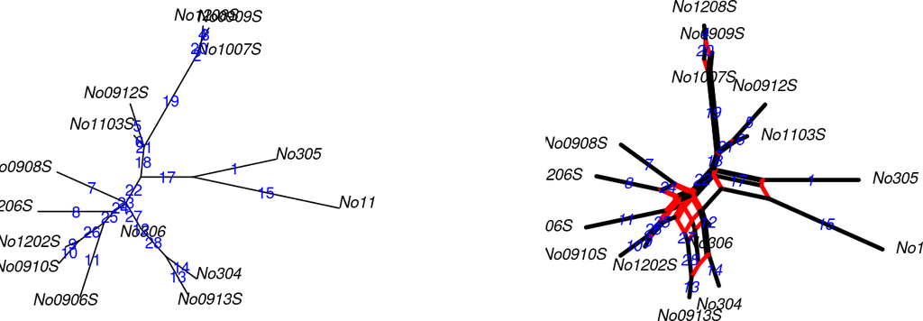

```r
# create a vector of labels for the network corresponding to edges in the tree
edge.lab <- createLabel(Nnet, raxml.tree, raxml.tree$edge[,2], "edge")
# could be also 1:27 instead of raxml.tree$edge[,2]

# Show the correspondingly labelled tree and network in R
par(mfrow=c(1,2))
plot(raxml.tree, "u", rotate.tree = 180, cex=.7)
edgelabels(raxml.tree$edge[,2],col="blue", frame="none", cex=.7)

# find edges that are in the network but not in the tree
edge.col <- rep("black", nrow(Nnet$edge))
edge.col[ is.na(edge.lab) ] <- "red"
# or a simpler alternative...
edge.col <- createLabel(Nnet, raxml.tree, "black", nomatch="red")

x <- plot(Nnet, edge.label = edge.lab, show.edge.label = T, "2D", edge.color =
          edge.col, col.edge.label = "blue", cex=.7)
```

The above plot function returns an invisible networx object and this object also contains the colors for the edges. One can export x as a nexusfile to read in with other software like Splitstree.

```
write.nexus.networx(x, file="colored_network.nex")
```

More examples are found in the `vignette("IntertwiningTreesAndNetworks")` and `vignette("Networx")`.